# Integrity, transparency, and accountability analysis

Viktoriia Poltoratskaia

2025-12-04

This R Markdown document presents an initial draft of the analysis on integrity, transparency, and accountability. It is based on ProAct open data for Uruguay and Bulgaria, with Uruguay serving as the baseline example. Data from Bulgaria are incorporated in instances where key variables are missing from the Uruguayan dataset.The underlying code is more extensive and detailed than the outputs presented here.

The first step is to assess data completeness by examining missing values across all variables or a defined subset. Given the limited number of variables in the ProAct dataset, a full review can be efficiently conducted to identify any variables with significant underreporting. Each variable contributed to one of the ProAct indicators.

## Overall missing-value shares (Uruguay)

Here is the output

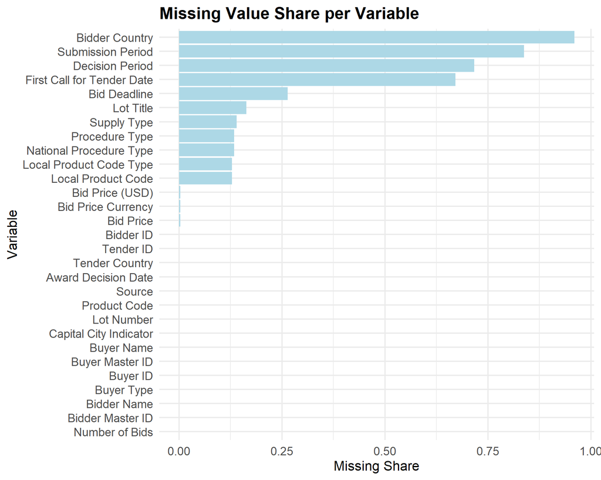

```r
missing_plot <- ggplot(
  missing_shares_long,
  aes(
    x = reorder(variable, missing_share),
    y = missing_share
  )
) +
  geom_col(fill = "lightblue") +
  coord_flip() +
  scale_x_discrete(
    labels = function(x) {
      out <- label_lookup[x]
      out[is.na(out)] <- x[is.na(out)]
      out
    }
  ) +
  labs(
    title = "Missing Value Share per Variable",
    x     = "Variable",
    y     = "Missing Share"
  ) +
  theme_minimal(base_size = 16) +
  theme(
    plot.title = element_text(size = 20, face = "bold"),
    axis.title = element_text(size = 16),
    axis.text  = element_text(size = 14)
  )

missing_plot
```

```r
ggsave(
  filename = file.path(output_dir_uy, "missing_shares_plot.png"),
  plot     = missing_plot,
  width    = 10,
  height   = 6,
  dpi      = 300
)
```

## Missing shares by buyer type (Uruguay)

Visualising

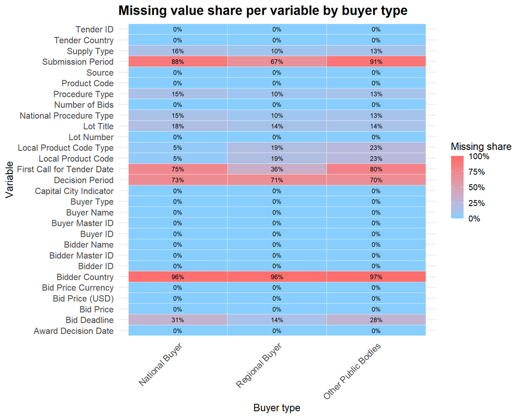

```r
missing_by_buyer_plot <- ggplot(
  missing_by_buyer,
  aes(
    x    = buyer_group,
    y    = variable_label,
    fill = missing_share
  )
) +
  geom_tile(color = "white") +
  geom_text(
    aes(label = scales::percent(missing_share, accuracy = 1)),
    size  = 3,
    color = "black"
  ) +
  scale_fill_gradient(
    name   = "Missing share",
    labels = scales::percent_format(accuracy = 1),
    limits = c(0, 1),
    low    = "skyblue1",
    high   = "indianred1"
  ) +
  labs(
    title = "Missing value share per variable by buyer type",
    x     = "Buyer type",
    y     = "Variable"
  ) +
  theme_minimal(base_size = 14) +
  theme(
    plot.title  = element_text(size = 18, face = "bold"),
    axis.title  = element_text(size = 14),
    axis.text.x = element_text(size = 12, angle = 45, hjust = 1),
    axis.text.y = element_text(size = 12)
  )

missing_by_buyer_plot
```

## Top buyers with highest overall missing share (Uruguay)

Visualising

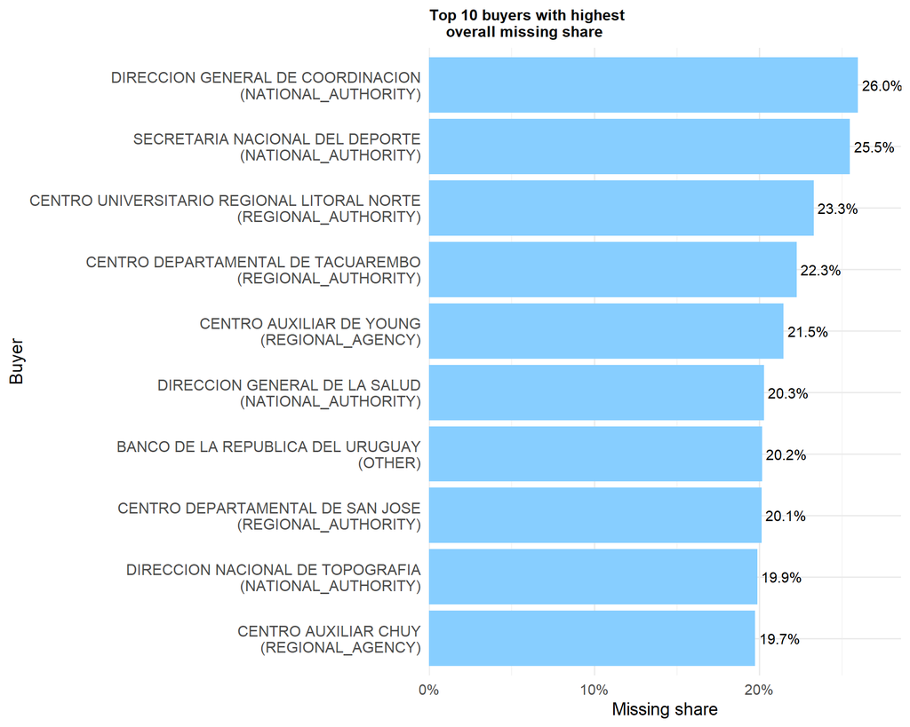

```r
missing_buyers <- ggplot(
  top10_buyers_missing,
  aes(
    x = reorder(buyer_label, missing_share),
    y = missing_share
  )
) +
  geom_col(fill = "skyblue1") +
  geom_text(
    aes(label = scales::percent(missing_share, accuracy = 0.1)),
    hjust = -0.1,
    size  = 4
  ) +
  coord_flip() +
  scale_y_continuous(
    labels = scales::percent_format(accuracy = 1),
    expand = expansion(mult = c(0, 0.1))
  ) +
  labs(
    title = "Top 10 buyers with highest
    overall missing share",
    x     = "Buyer",
    y     = "Missing share"
  ) +
  theme_minimal(base_size = 14) +
  theme(
    plot.title  = element_text(size = 12, face = "bold"),
    axis.text.y = element_text(size = 12, lineheight = 0.9)
  )

missing_buyers
```

National and other public bodies report a little less consistently than regional entities, particularly regarding deadlines and procedure types. The Ministry of Public Health and the Ministry of Sport show the highest levels of underreporting. Given their extensive procurement activities, including large infrastructure projects, improving disclosure of dates and procedure information would significantly strengthen transparency.

## Missing shares by procedure type (Uruguay)

Visualising

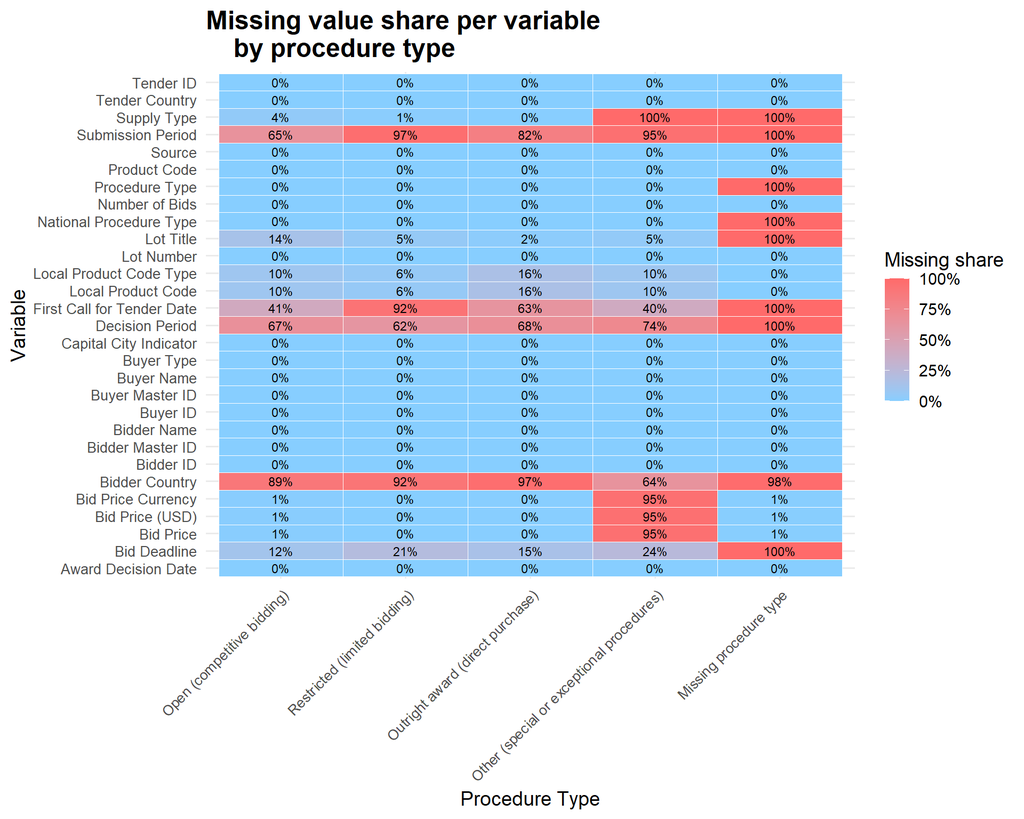

```r
missing_by_proc_plot <- ggplot(
  missing_by_proc,
  aes(
    x    = proc_group_label,
    y    = variable_label,
    fill = missing_share
  )
) +
  geom_tile(color = "white") +
  geom_text(
    aes(label = scales::percent(missing_share, accuracy = 1)),
    size  = 3,
    color = "black"
  ) +
  scale_fill_gradient(
    name   = "Missing share",
    labels = scales::percent_format(accuracy = 1),
    limits = c(0, 1),
    low    = "skyblue1",
    high   = "indianred1"
  ) +
  labs(
    title = "Missing value share per variable
    by procedure type",
    x     = "Procedure Type",
    y     = "Variable"
  ) +
  theme_minimal(base_size = 14) +
  theme(
    plot.title  = element_text(size = 18, face = "bold"),
    axis.title  = element_text(size = 14),
    axis.text.x = element_text(size = 10, angle = 45, hjust = 1),
    axis.text.y = element_text(size = 10)
  )

missing_by_proc_plot
```

```r
ggsave(
  filename = file.path(output_dir_uy, "missing_by_proc_plot.png"),
  plot     = missing_by_proc_plot,
  width    = 10,
  height   = 6,
  dpi      = 300
)
```

## Missing shares over time (by tender year, Uruguay)

Analyzing missing values by year, quarter, or month helps identify whether underreporting stems from publication practices - for example, delays in updating recent records, platform transitions, or uneven reporting across periods.

Visualising

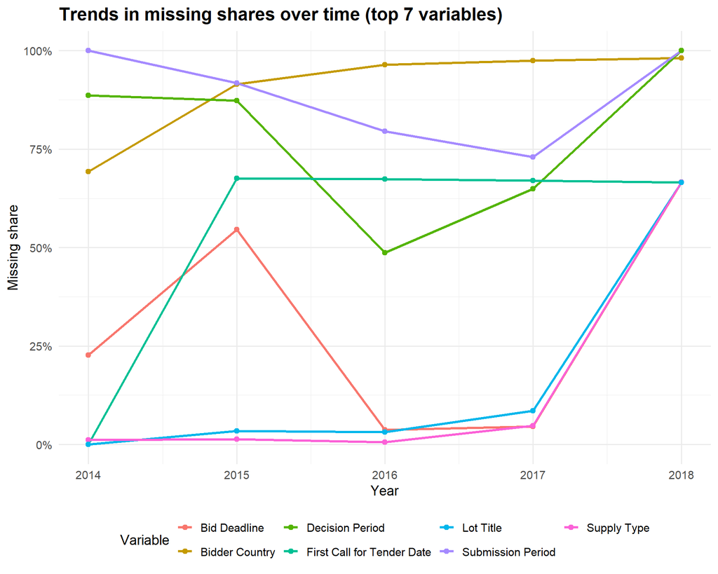

```r
year_miss <- missing_by_year %>%
  filter(variable_label %in% top_vars) %>%
  ggplot(
    aes(
      x     = tender_year,
      y     = missing_share,
      color = variable_label
    )
  ) +
  geom_line(size = 1.2) +
  geom_point(size = 2) +
  scale_y_continuous(labels = scales::percent_format(accuracy = 1)) +
  labs(
    title = "Trends in missing shares over time (top 7 variables)",
    x     = "Year",
    y     = "Missing share",
    color = "Variable"
  ) +
  theme_minimal(base_size = 14) +
  theme(
    plot.title      = element_text(size = 18, face = "bold"),
    legend.position = "bottom"
  )
year_miss
```

```r
ggsave(
  filename = file.path(output_dir_uy, "year_miss.png"),
  plot     = year_miss,
  width    = 10,
  height   = 6,
  dpi      = 300
)
```

In Uruguay, 2018 appears to be the last year of data updates. The highest missing rates occur in the initial year of publication when the transition to the online platform began and data were incomplete, and then again in 2018, likely reflecting partial publication during the final data upload.

Not all of the key variables are present in Uruguay, so we use Bulgarian data to complement the examples with more populated dataset.

## Missing share by buyer location (BG, NUTS3)

Analyzing missing values by region or municipality can reveal whether local buyers systematically underreport compared to national entities. While buyer location data are unavailable for Uruguay, Bulgaria illustrates the approach. Missing value shares vary little across NUTS3 regions (within four percentage points), with the outskirts of Sofia showing slightly lower reporting rates.

Visualising

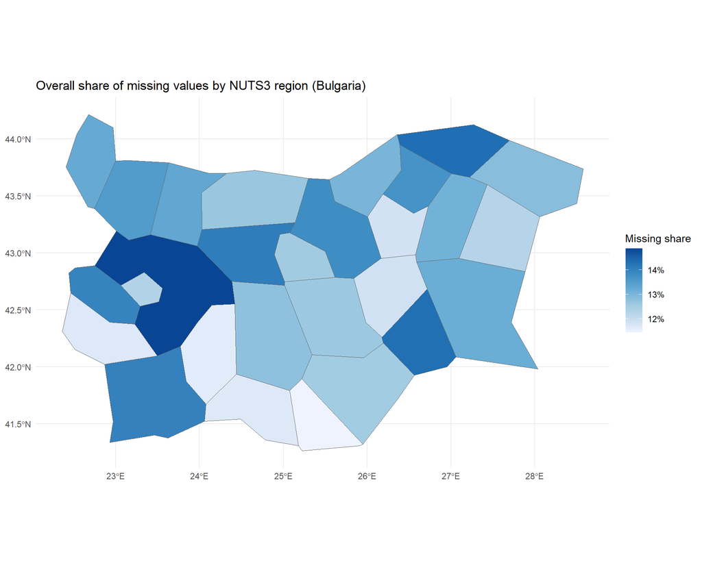

```r
bg_map <- ggplot(bg_map_data) +
  geom_sf(aes(fill = missing_share), color = "grey40", size = 0.2) +
  scale_fill_distiller(
    palette   = "Blues",
    direction = 1,
    na.value  = "grey90",
    labels    = scales::percent_format(accuracy = 1),
    name      = "Missing share"
  ) +
  labs(
    title = "Overall share of missing values by NUTS3 region (Bulgaria)"
  ) +
  theme_minimal()

bg_map
```

```r
ggsave(
  filename = file.path(output_dir_bg, "bg_map.png"),
  plot     = bg_map,
  width    = 10,
  height   = 6,
  dpi      = 300
)
```

## Unusual supplier market entries by CPV cluster (Uruguay)

We identify atypical market entry in public procurement by analyzing winners across CPV (Common Procurement Vocabulary) clusters and mapping statistically unusual cross-sector movements. First, we group contract awards by bidder and 3-digit CPV cluster and compute each bidder’s portfolio in that cluster (number and value of awards, and its share in the bidder’s total activity). We then restrict attention to bidders with sufficient history (≥4 awards or > 25th percentile) and flag “atypical” markets where a cluster represents less than 5 percent of the bidder’s portfolio and no more than three wins. In parallel, for every bidder–cluster pair we estimate the conditional probability of a bidder winning in that cluster, based on all awards in the market, and derive a surprise score (the negative log of this probability, standardized to a z-score). Each bidder’s “home market” is defined as the cluster where it wins the most awards; atypical wins in other clusters are treated as unusual entries. Aggregating these entries to the level of home-cluster → target-cluster pairs, we count how many distinct bidders make each move and compute the average standardized surprise. The resulting directed network of CPV clusters uses edge thickness to reflect the number of bidders involved and edge color to reflect the mean surprise level, highlighting markets and market pairs where cross-sector participation is unusually frequent and may warrant closer integrity and classification review.

Visualising

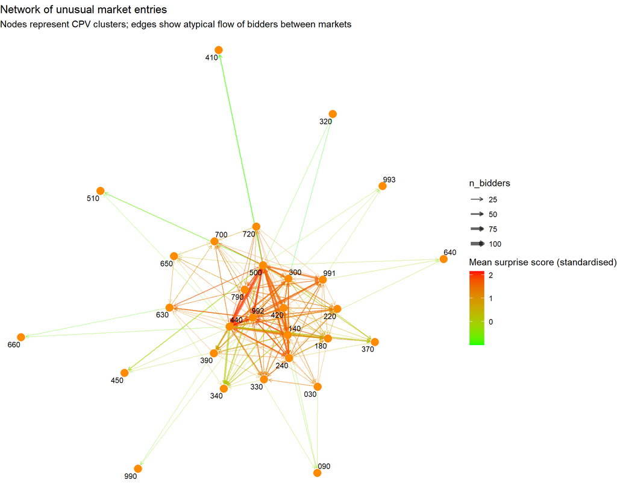

```r
# 5. Network visualisation of unusual market entries ---------------------

edges_markets <- unusual_matrix %>%
  filter(n_bidders >= 4) %>%   # threshold to avoid “hairball” network
  rename(
    from = home_cpv_cluster,
    to   = target_cpv_cluster
  )

g_markets <- graph_from_data_frame(edges_markets, directed = TRUE)

uy_supp_net <- ggraph(g_markets, layout = "fr") +
  geom_edge_link(
    aes(width = n_bidders, colour = mean_surprise),
    arrow   = arrow(length = grid::unit(0.15, "cm")),
    end_cap = circle(2, "mm"),
    alpha   = 0.6
  ) +
  geom_node_point(size = 4, colour = "darkorange") +
  geom_node_text(aes(label = name), repel = TRUE, size = 3) +
  scale_edge_width(range = c(0.2, 2)) +
  scale_edge_colour_continuous(
    low  = "green",
    high = "red",
    name = "Mean surprise score (standardised)"
  ) +
  labs(
    title    = "Network of unusual market entries",
    subtitle = "Nodes represent CPV clusters; edges show atypical flow of bidders between markets"
  ) +
  theme_void()

uy_supp_net
```

```r
ggsave(
  filename = file.path(output_dir_uy, "UY_supp_net.png"),
  plot     = uy_supp_net,
  width    = 10,
  height   = 6,
  dpi      = 300
)
```

The dense central network of interconnected procurement clusters suggests a dynamic marketplace where firms actively participate in a range of related goods and services. However, the presence of several thick, red edges—indicating statistically atypical cross-sector movements—also points to potential vulnerabilities. These unusual entries may reflect either legitimate diversification or irregularities such as weak classification practices, strategic bidding, or limited enforcement of specialization standards. While the overall structure does not suggest systemic concentration or market capture, the data highlight the importance of monitoring outlier patterns, particularly in highly interconnected sectors like construction, maintenance, and professional services.

## Buyer–supplier concentration (Uruguay)

This analysis measures the share of a buyer’s total annual spending that goes to a single supplier. In other words, it examines how concentrated a buyer’s expenditures are among specific suppliers, focusing on the total value of contracts rather than the number of contracts.

Visualising

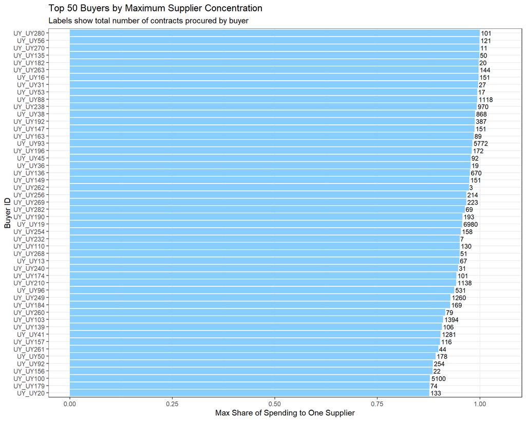

```r
bc_overall <- ggplot(
  top_buyers,
  aes(
    x = reorder(buyer_masterid, max_conc),
    y = max_conc
  )
) +
  geom_col(fill = "skyblue1") +
  geom_text(
    aes(label = total_contracts),
    hjust = -0.1,
    size  = 3.2
  ) +
  coord_flip() +
  theme_bw() +
  labs(
    title    = "Top 50 Buyers by Maximum Supplier Concentration",
    subtitle = "Labels show total number of contracts procured by buyer",
    x        = "Buyer ID",
    y        = "Max Share of Spending to One Supplier"
  ) +
  ylim(0, 1.05)

bc_overall
```

```r
ggsave(
  filename = file.path(output_dir_uy, "bc_overall.png"),
  plot     = bc_overall,
  width    = 10,
  height   = 8,
  dpi      = 300
)
```

## Buyer–supplier concentration by year (Uruguay)

Visualising

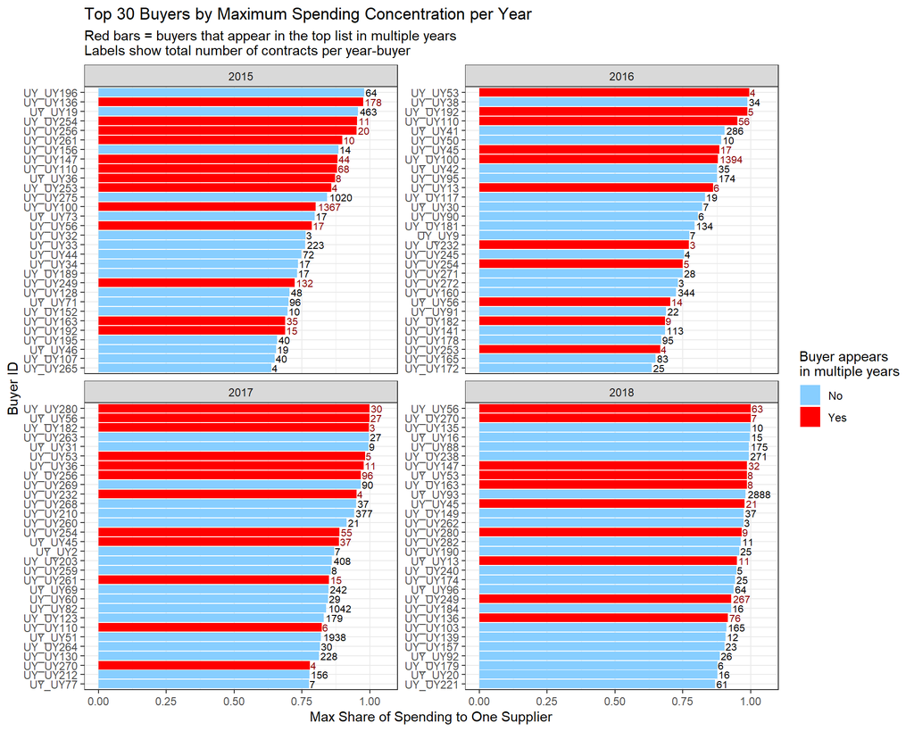

```r
bc_yearly <- ggplot(
  top_buyers_yearly,
  aes(
    x     = reorder_within(buyer_masterid, max_conc, tender_year),
    y     = max_conc,
    fill  = repeated
  )
) +
  geom_col() +
  geom_text(
    aes(label = total_contracts, color = repeated),
    hjust       = -0.1,
    size        = 2.8,
    show.legend = FALSE
  ) +
  coord_flip() +
  facet_wrap(~ tender_year, scales = "free_y") +
  scale_x_reordered() +
  scale_fill_manual(
    values = c(`FALSE` = "skyblue1", `TRUE` = "red"),
    name   = "Buyer appears\nin multiple years",
    labels = c("No", "Yes")
  ) +
  scale_color_manual(
    values = c(`FALSE` = "black", `TRUE` = "red4")
  ) +
  theme_bw(base_size = 11) +
  labs(
    title    = "Top 30 Buyers by Maximum Spending Concentration per Year",
    subtitle = "Red bars = buyers that appear in the top list in multiple years\nLabels show total number of contracts per year-buyer",
    x        = "Buyer ID",
    y        = "Max Share of Spending to One Supplier"
  ) +
  ylim(0, 1.05)

bc_yearly
```

```r
ggsave(
  filename = file.path(output_dir_uy, "bc_yearly.png"),
  plot     = bc_yearly,
  width    = 10,
  height   = 8,
  dpi      = 300
)
```

In Uruguay, it appears that many buyers award nearly all (more than 75%) of their total contract value to the same supplier, and that multiple buyers do so consistently over several years. These cases require closer examination, as such a concentration of spending may indicate potentially suspicious relationships, although this depends on the type of tenders and the characteristics of the market.

## Effect of non-transparency on competition (Uruguay)

Running model and visualising

```r
model_fe_uy <- feols(
  cumulative_singleb_rate ~ cumulative_missing_share +
    log1p(n_contracts) +
    log1p(avg_contract_value) |
    buyer_masterid + tender_year,
  data = buyer_analysis
)
```

```
## NOTES: 12 observations removed because of NA values (LHS: 12).
##        9/0 fixed-effect singletons were removed (9 observations).
```

```r
summary(model_fe_uy)
```

```
## OLS estimation, Dep. Var.: cumulative_singleb_rate
## Observations: 947
## Fixed-effects: buyer_masterid: 259,  tender_year: 4
## Standard-errors: IID
##                            Estimate Std. Error   t value Pr(>|t|)
## cumulative_missing_share  44.708745  18.852166  2.371544 0.017991 *
## log1p(n_contracts)        -2.092566   0.883663 -2.368058 0.018160 *
## log1p(avg_contract_value)  0.414607   0.490614  0.845077 0.398364
## ---
## Signif. codes:  0 '***' 0.001 '**' 0.01 '*' 0.05 '.' 0.1 ' ' 1
## RMSE: 14.6     Adj. R2: 0.379165
##              Within R2: 0.015308
```

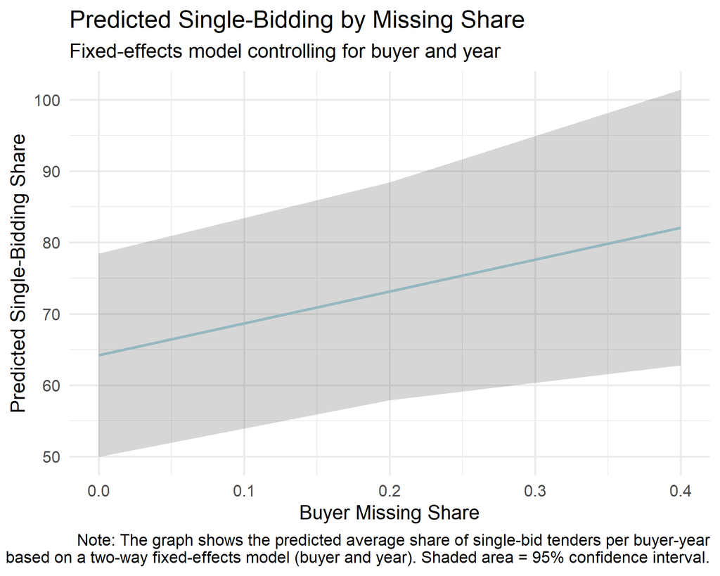

```r
pred_uy <- ggpredict(model_fe_uy, terms = "cumulative_missing_share")

reg_uy <- ggplot(pred_uy, aes(x, predicted)) +
  geom_line(size = 1.5, color = "lightblue") +
  geom_ribbon(aes(ymin = conf.low, ymax = conf.high), alpha = 0.2) +
  labs(
    title    = "Predicted Single-Bidding by Missing Share",
    subtitle = "Fixed-effects model controlling for buyer and year",
    x        = "Buyer Missing Share",
    y        = "Predicted Single-Bidding Share",
    caption  = "Note: The graph shows the predicted average share of single-bid tenders per buyer-year\nbased on a two-way fixed-effects model (buyer and year). Shaded area = 95% confidence interval."
  ) +
  theme_minimal(base_size = 20)

reg_uy
```

```r
ggsave(
  filename = file.path(output_dir_uy, "reg_singleb_missing_share.png"),
  plot     = reg_uy,
  width    = 10,
  height   = 8,
  dpi      = 300
)
```

## Effect on relative price in BG

Running model and visualising

```r
model_lm_bg <- lm(
  relative_price ~ total_missing_share +
    buyer_buyertype +
    tender_proceduretype +
    as.factor(tender_year),
  data = bg_proact_reg
)

summary(model_lm_bg)
```

```
##
## Call:
## lm(formula = relative_price ~ total_missing_share + buyer_buyertype +
##     tender_proceduretype + as.factor(tender_year), data = bg_proact_reg)
##
## Residuals:
##     Min      1Q  Median      3Q     Max
## -1.2008 -0.2130 -0.0459  0.0711  4.1069
##
## Coefficients:
##                                                     Estimate Std. Error t value
## (Intercept)                                         1.044580   0.025307  41.277
## total_missing_share                                 0.410248   0.266062   1.542
## buyer_buyertypeEUROPEAN_AGENCY                      0.059882   0.196029   0.305
## buyer_buyertypeNATIONAL_AGENCY                     -0.024095   0.037851  -0.637
## buyer_buyertypeNATIONAL_AUTHORITY                  -0.037180   0.018429  -2.018
## buyer_buyertypeOTHER                                0.088215   0.022684   3.889
## buyer_buyertypePUBLIC_BODY                          0.131140   0.015819   8.290
## buyer_buyertypeREGIONAL_AGENCY                      0.005050   0.337934   0.015
## buyer_buyertypeREGIONAL_AUTHORITY                  -0.007534   0.017125  -0.440
## tender_proceduretypeCOMPETITIVE_DIALOG              0.085749   0.675413   0.127
## tender_proceduretypeNEGOTIATED                     -0.046135   0.046868  -0.984
## tender_proceduretypeNEGOTIATED_WITH_PUBLICATION    -0.021513   0.027352  -0.787
## tender_proceduretypeNEGOTIATED_WITHOUT_PUBLICATION -0.080996   0.049861  -1.624
## tender_proceduretypeRESTRICTED                     -0.039601   0.098778  -0.401
## as.factor(tender_year)2013                         -0.144930   0.023728  -6.108
## as.factor(tender_year)2014                         -0.146135   0.022266  -6.563
## as.factor(tender_year)2015                         -0.079410   0.021832  -3.637
## as.factor(tender_year)2016                         -0.094211   0.022767  -4.138
## as.factor(tender_year)2017                         -0.096904   0.024375  -3.976
## as.factor(tender_year)2018                         -0.087693   0.023647  -3.708
## as.factor(tender_year)2019                         -0.114972   0.023847  -4.821
## as.factor(tender_year)2020                         -0.097145   0.045039  -2.157
##                                                    Pr(>|t|)
## (Intercept)                                         < 2e-16 ***
## total_missing_share                                0.123105
## buyer_buyertypeEUROPEAN_AGENCY                     0.760006
## buyer_buyertypeNATIONAL_AGENCY                     0.524408
## buyer_buyertypeNATIONAL_AUTHORITY                  0.043655 *
## buyer_buyertypeOTHER                               0.000101 ***
```

[output cut: 8 more lines]

```
## as.factor(tender_year)2013                         1.03e-09 ***
## as.factor(tender_year)2014                         5.38e-11 ***
## as.factor(tender_year)2015                         0.000276 ***
## as.factor(tender_year)2016                         3.52e-05 ***
## as.factor(tender_year)2017                         7.04e-05 ***
## as.factor(tender_year)2018                         0.000209 ***
## as.factor(tender_year)2019                         1.44e-06 ***
## as.factor(tender_year)2020                         0.031024 *
## ---
## Signif. codes:  0 '***' 0.001 '**' 0.01 '*' 0.05 '.' 0.1 ' ' 1
##
## Residual standard error: 0.6752 on 22236 degrees of freedom
##   (103468 observations deleted due to missingness)
## Multiple R-squared:  0.01463,    Adjusted R-squared:  0.0137
## F-statistic: 15.72 on 21 and 22236 DF,  p-value: < 2.2e-16
```

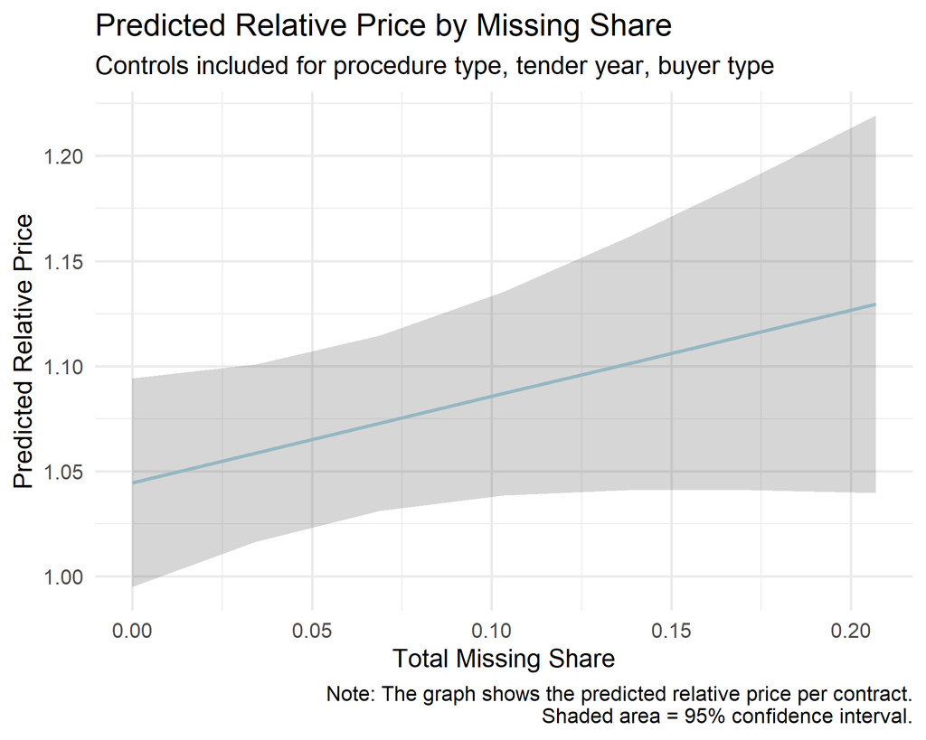

```r
pred_bg <- ggpredict(model_lm_bg, terms = "total_missing_share")

reg_bg <- ggplot(pred_bg, aes(x, predicted)) +
  geom_line(size = 1.5, color = "lightblue") +
  geom_ribbon(aes(ymin = conf.low, ymax = conf.high), alpha = 0.2) +
  labs(
    title    = "Predicted Relative Price by Missing Share",
    subtitle = "Controls included for procedure type, tender year, buyer type",
    x        = "Total Missing Share",
    y        = "Predicted Relative Price",
    caption  = "Note: The graph shows the predicted relative price per contract.\nShaded area = 95% confidence interval."
  ) +
  theme_minimal(base_size = 20)

reg_bg
```

```r
ggsave(
  filename = file.path(output_dir_bg, "reg_relative_price_missing_share.png"),
  plot     = reg_bg,
  width    = 10,
  height   = 8,
  dpi      = 300
)
```

Based on the analysis, a high proportion of missing values in key contract-level fields is associated with an increase in the relative price. When no information is missing, the predicted relative price is approximately 1.05 - close to the originally estimated price. However, when up to 20% of the data is missing, the predicted relative price rises to 1.13, indicating a tendency toward more overpriced contracts.